## Machine Learning Assignment

### Qualitative Activity Recognition of Weight Lifting Exercises

**Author: Oliver Morris. Date: September 2015**

## Executive Summary

This report investigates data resulting from an experiment into the classification of weight lifting exercises (Velloso, E. et al, 2013). These exercises were performed by people instructed to perform lifting exercises in one correct manner, and four incorrect manners.

The report finds two types of data available from the experiment and proceeds to explore classification models and the ways in which those models can be tuned.

The most accurate model is found to be a random forest, involving 500 trees but reporting only 2 misclassifications in 1000 observations. A notable mention is made of the quadratic discriminant analysis which achieves high accuracy despite taking only 0.5% of the processor time to construct when compared with a random forest.

## Investigation of the Experiment Data

The training set is 19,622 accelerometer and gyroscope observations, taken at approx 50 observations per second (50Hz). There are 160 columns, with the last being the outcome ‘Class’. Class ‘A’ is a correctly performed lift, B to E are incorrectly performed. There are two types of record in the data, as distinguished by the ‘new_window’ flag being either “yes” or “no”. Records with “yes” include a number of averages taken over the previous one second of measurements. Those with “no”, exclude these averages.

**Arrangement of Equipment in Experiment (Velloso, E. et al, 2013)**

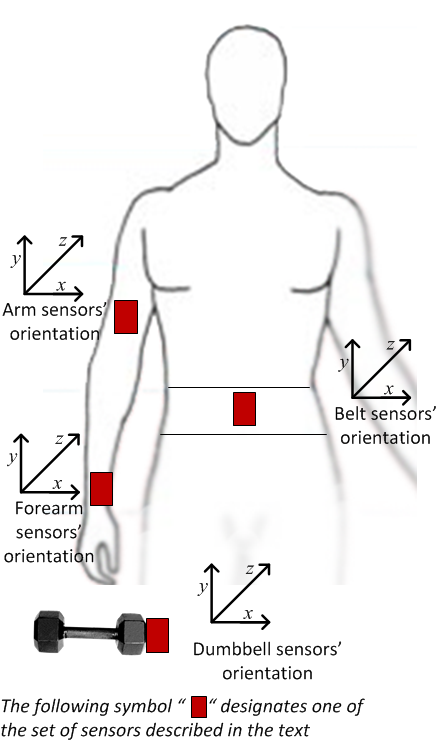

**Importing the Data**

The data was reviewed and all complete columns were selected for the raw data (where ‘new_window’ is flagged ‘no’). The 1s average data (flagged ‘yes’) includes all columns populated only for the 1s average. Both sets exclude columns which are of no interest to any model, such as the name of the tester and the clock time of the measurement.

```r
## Load the training data
dat <- read.csv("pml-training.csv")

## Manually select columns for each data group, with outcome 'classe' in first column
cols_RAW <- c(160,7,8,9,10,11,37,38,39,40,41,42,43,44,45,46,47,48,49,60,
              61,62,63,64,65,66,67,68,84,85,86,102,113,114,115,116,117,118,
              119,120,121,122,123,124,140,151,152,153,154,155,156,157,158,159)
dat_RAW <- dat[,cols_RAW]

## Ensure all rows are complete and all numeric columns are indeed numeric, not factors
## except the outcome 'classe', which is column 1.
dat_RAW <- dat_RAW[complete.cases(dat_RAW),]
for(i in c(2:ncol(dat_RAW))) {
  dat_RAW[,i] <- as.numeric(dat_RAW[,i])
}
############################################################
## Repeat process for the 1s average data rows.
############################################################
## Manually select columns for each data group, with outcome 'classe' in first column
cols_1sAvg <-c (160,7,8,9,10,11,12,15,18,19,20,21,22,23,24,25,26,
                27,28,29,30,31,32,33,34,35,36,50,51,52,53,54,55,56,
                57,58,59,69,72,75,76,77,78,79,80,81,82,83,87,88,90,
                91,93,94,95,96,97,98,99,100,101,103,104,105,106,107,
                108,109,110,111,112,125,126,128,129,131,132,133,134,
                135,136,137,138,139,141,142,143,144,145,146,147,148,
                149,150)
dat_1sAvg <- dat[dat$new_window=="yes",cols_1sAvg]

## Ensure all rows are complete and all numeric columns are indeed numeric, not factors,
## except the outcome 'classe', which is column 1.
dat_1sAvg <- dat_1sAvg[complete.cases(dat_1sAvg),]
for(i in c(2:ncol(dat_1sAvg))) {
  dat_1sAvg[,i] <- as.numeric(dat_1sAvg[,i])
}
```

**Visualising the Data**

Such a large number of predictors is not easily visualised. However, all the accelerometers share a calibrated orientation, i.e. the x, y, z, orientation is the same for each. This implies that the data can be visualised by combining all x values, y values and z values for a given observation using Principal Component Analysis, resulting in a single x,y,z for each observation. The same could also be done for rotational movement; roll, pitch and yaw. This approach to visualisation is shown below, where colours represent classes: Red=A, Green=B, Blue=C, Yellow=D, Purple=E

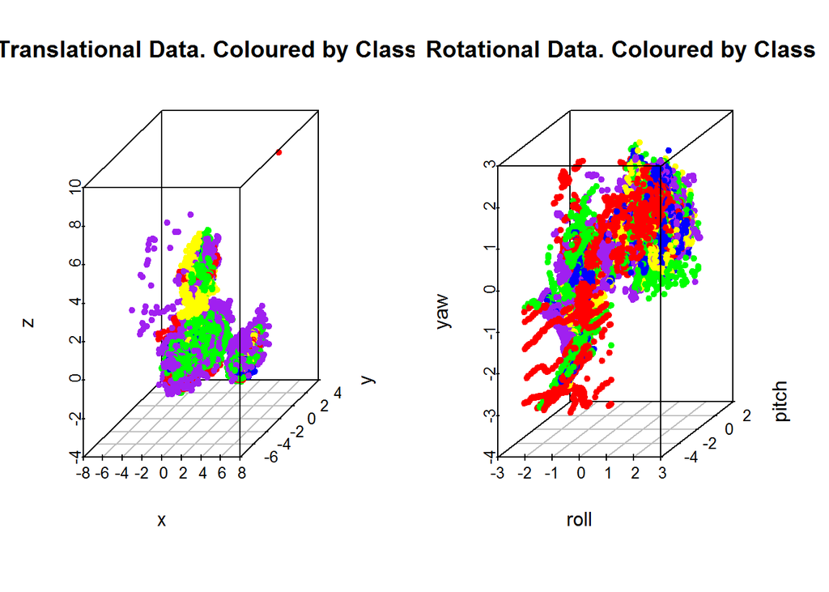

```r
require(caret)

##Select columns relevant to translational movement in x, y, z
cols_x <- c(157,154,151,119,116,113,66,63,60,43,40,37)
cols_y <- c(158,155,152,120,117,114,67,64,61,44,41,38)
cols_z <- c(159,156,153,121,118,115,68,65,62,45,42,39)

##Select columns relevant to rotational movement in roll, pitch, yaw
cols_roll <- c(122,84,46,8)
cols_pitch <- c(123,85,47,9)
cols_yaw <- c(124,86,48,10)

## Create function to parse the columns and reduce them to one principal component
## this single component will be; x, y or z; roll, pitch or yaw.
unify <- function(columnlist, rawdata)
  {
    dat_axis <- rawdata[,columnlist]
    for(j in c(1:ncol(dat_axis))) {
      dat_axis[,j] <- as.numeric(dat_axis[,j])
    }
    preProc_axis <- preProcess(dat_axis, method=c("pca"), pcaComp = 1)
    result <- predict(preProc_axis, dat_axis)
    return(result)
}

##Create a table of classe,x,y,z
unified_translate <- cbind(dat[,160], unify(cols_x, dat),unify(cols_y, dat),unify(cols_z, dat))
names(unified_translate) <- paste(c("classe", "x","y","z"))

##Create a table of classe, roll, pitch, yaw movements
unified_rotate <- cbind(dat[,160], unify(cols_roll, dat),unify(cols_pitch, dat),unify(cols_yaw, dat))
names(unified_rotate) <- paste(c("classe","roll","pitch","yaw"))

##Change levels to colours for plotting
levels(unified_translate$classe) <- c("red","green","blue","yellow","purple")
levels(unified_rotate$classe) <- c("red","green","blue","yellow","purple")

##Present the results using the scatterplot3d package
require(scatterplot3d)
par(mfrow=c(1,2))
with(unified_translate, {
  scatterplot3d(x, y, z, angle=30, color=classe, pch=20,
                main="Translational Data. Coloured by Class")
})
with(unified_rotate, {
  scatterplot3d(roll, pitch, yaw, angle=30, color=classe, pch=20,
                main="Rotational Data. Coloured by Class")
})
```

The visualisation shows some grouping, but also shows how intermixed the classes are. Classificaiton will not be simple. No further attempt was made to visualise the data.